# variable

a varibale is symbol which works as a placeholder for expression of quantities that may vary or change, variable can be characteristics number or quantity that cna be measured or counted.

# type of variable

1. numerical
- discrete Continuous variable- Continuous variables are numeric variables that have an infinite number of values between any two values. A continuous variable can be numeric or date/time. For example, the length of a part or the date and time a payment is received. Discrete variable- Discrete variables are numeric variables that have a countable number of values between any two values. A discrete variable is always numeric. For example, the number of customer complaints or the number of flaws or defects.
- continous
1. categorical
- ordinal
- nominal
1. nominal- A categorical variable (sometimes called a nominal variable) is one that has two or more categories, but there is no intrinsic ordering to the categories
2. Ordinal- An ordinal variable is similar to a categorical variable. The difference between the two is that there is a clear ordering of the categories. For example, suppose you have a variable, economic status, with three categories (low, medium and high).
3. data and time
4. mixed

# imputation technique

measure of centeral tendency (mean, meadin, mode) with each class or missing indicator

```python
import pandas as pd
import numpy as np
import seaborn as sns
import matplotlib.pyplot as plt
import os
plt.figure(figsize=(15,15))
```

```python
data = pd.read_csv('C:/Users/deepak kumar/Desktop/houseprice.csv')
data.head()
```

|  | Id | MSSubClass | MSZoning | LotFrontage | LotArea | Street | Alley | LotShape | LandContour | Utilities | ... | PoolArea | PoolQC | Fence | MiscFeature | MiscVal | MoSold | YrSold | SaleType | SaleCondition | SalePrice |
| --- | --- | --- | --- | --- | --- | --- | --- | --- | --- | --- | --- | --- | --- | --- | --- | --- | --- | --- | --- | --- | --- |
| 0 | 1 | 60 | RL | 65.0 | 8450 | Pave | NaN | Reg | Lvl | AllPub | ... | 0 | NaN | NaN | NaN | 0 | 2 | 2008 | WD | Normal | 208500 |
| 1 | 2 | 20 | RL | 80.0 | 9600 | Pave | NaN | Reg | Lvl | AllPub | ... | 0 | NaN | NaN | NaN | 0 | 5 | 2007 | WD | Normal | 181500 |
| 2 | 3 | 60 | RL | 68.0 | 11250 | Pave | NaN | IR1 | Lvl | AllPub | ... | 0 | NaN | NaN | NaN | 0 | 9 | 2008 | WD | Normal | 223500 |
| 3 | 4 | 70 | RL | 60.0 | 9550 | Pave | NaN | IR1 | Lvl | AllPub | ... | 0 | NaN | NaN | NaN | 0 | 2 | 2006 | WD | Abnorml | 140000 |
| 4 | 5 | 60 | RL | 84.0 | 14260 | Pave | NaN | IR1 | Lvl | AllPub | ... | 0 | NaN | NaN | NaN | 0 | 12 | 2008 | WD | Normal | 250000 |

5 rows × 81 columns

```python
#check the missing values in boolean
data.isnull().head()
```

|  | Id | MSSubClass | MSZoning | LotFrontage | LotArea | Street | Alley | LotShape | LandContour | Utilities | ... | PoolArea | PoolQC | Fence | MiscFeature | MiscVal | MoSold | YrSold | SaleType | SaleCondition | SalePrice |
| --- | --- | --- | --- | --- | --- | --- | --- | --- | --- | --- | --- | --- | --- | --- | --- | --- | --- | --- | --- | --- | --- |
| 0 | False | False | False | False | False | False | True | False | False | False | ... | False | True | True | True | False | False | False | False | False | False |
| 1 | False | False | False | False | False | False | True | False | False | False | ... | False | True | True | True | False | False | False | False | False | False |
| 2 | False | False | False | False | False | False | True | False | False | False | ... | False | True | True | True | False | False | False | False | False | False |
| 3 | False | False | False | False | False | False | True | False | False | False | ... | False | True | True | True | False | False | False | False | False | False |
| 4 | False | False | False | False | False | False | True | False | False | False | ... | False | True | True | True | False | False | False | False | False | False |

5 rows × 81 columns

```python
#count the all missing valus of particular columns
data.isnull().sum()
```

```
Id                 0
MSSubClass         0
MSZoning           0
LotFrontage      259
LotArea            0
                ...
MoSold             0
YrSold             0
SaleType           0
SaleCondition      0
SalePrice          0
Length: 81, dtype: int64
```

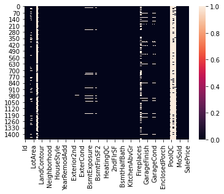

```python
#plot the heaptmap wiht null values
sns.heatmap(data.isnull())
```

```python
#print those columns name which have missing values
[col for col in data.columns if data[col].isnull().sum()>0]
```

```
['LotFrontage',
 'Alley',
 'MasVnrType',
 'MasVnrArea',
 'BsmtQual',
 'BsmtCond',
 'BsmtExposure',
 'BsmtFinType1',
 'BsmtFinType2',
 'Electrical',
 'FireplaceQu',
 'GarageType',
 'GarageYrBlt',
 'GarageFinish',
 'GarageQual',
 'GarageCond',
 'PoolQC',
 'Fence',
 'MiscFeature']
```

```python
#make a list of the variable that contain missing values
var_with_na = [var for var in data.columns if data[var].isnull().sum()>1]
#print the variable name and the pricentage of missing values
for var in data:
    print(var,np.round(data[var].isnull().mean(),3), '% missing values')
```

```
Id 0.0 % missing values
MSSubClass 0.0 % missing values
MSZoning 0.0 % missing values
LotFrontage 0.177 % missing values
LotArea 0.0 % missing values
Street 0.0 % missing values
Alley 0.938 % missing values
LotShape 0.0 % missing values
LandContour 0.0 % missing values
Utilities 0.0 % missing values
LotConfig 0.0 % missing values
LandSlope 0.0 % missing values
Neighborhood 0.0 % missing values
Condition1 0.0 % missing values
Condition2 0.0 % missing values
BldgType 0.0 % missing values
HouseStyle 0.0 % missing values
OverallQual 0.0 % missing values
OverallCond 0.0 % missing values
YearBuilt 0.0 % missing values
YearRemodAdd 0.0 % missing values
RoofStyle 0.0 % missing values
RoofMatl 0.0 % missing values
Exterior1st 0.0 % missing values
Exterior2nd 0.0 % missing values
MasVnrType 0.005 % missing values
MasVnrArea 0.005 % missing values
ExterQual 0.0 % missing values
ExterCond 0.0 % missing values
Foundation 0.0 % missing values
BsmtQual 0.025 % missing values
BsmtCond 0.025 % missing values
BsmtExposure 0.026 % missing values
BsmtFinType1 0.025 % missing values
BsmtFinSF1 0.0 % missing values
BsmtFinType2 0.026 % missing values
BsmtFinSF2 0.0 % missing values
BsmtUnfSF 0.0 % missing values
TotalBsmtSF 0.0 % missing values
Heating 0.0 % missing values
```

[output cut: 26 more lines]

```
WoodDeckSF 0.0 % missing values
OpenPorchSF 0.0 % missing values
EnclosedPorch 0.0 % missing values
3SsnPorch 0.0 % missing values
ScreenPorch 0.0 % missing values
PoolArea 0.0 % missing values
PoolQC 0.995 % missing values
Fence 0.808 % missing values
MiscFeature 0.963 % missing values
MiscVal 0.0 % missing values
MoSold 0.0 % missing values
YrSold 0.0 % missing values
SaleType 0.0 % missing values
SaleCondition 0.0 % missing values
SalePrice 0.0 % missing values
```

# numerical variables

```python
#let access the all numerical feature
data.select_dtypes(include=['int64' ,'float']).columns
```

```
Index(['Id', 'MSSubClass', 'LotFrontage', 'LotArea', 'OverallQual',
       'OverallCond', 'YearBuilt', 'YearRemodAdd', 'MasVnrArea', 'BsmtFinSF1',
       'BsmtFinSF2', 'BsmtUnfSF', 'TotalBsmtSF', '1stFlrSF', '2ndFlrSF',
       'LowQualFinSF', 'GrLivArea', 'BsmtFullBath', 'BsmtHalfBath', 'FullBath',
       'HalfBath', 'BedroomAbvGr', 'KitchenAbvGr', 'TotRmsAbvGrd',
       'Fireplaces', 'GarageYrBlt', 'GarageCars', 'GarageArea', 'WoodDeckSF',
       'OpenPorchSF', 'EnclosedPorch', '3SsnPorch', 'ScreenPorch', 'PoolArea',
       'MiscVal', 'MoSold', 'YrSold', 'SalePrice'],
      dtype='object')
```

```python
#list of the all numerical variable from the dataset and count it
num_var = [var for var in data.columns if data[var].dtypes != 'O']
print("number of numerical variable:",len(num_var))
data[num_var].head()
```

```
number of numerical variable: 38
```

|  | Id | MSSubClass | LotFrontage | LotArea | OverallQual | OverallCond | YearBuilt | YearRemodAdd | MasVnrArea | BsmtFinSF1 | ... | WoodDeckSF | OpenPorchSF | EnclosedPorch | 3SsnPorch | ScreenPorch | PoolArea | MiscVal | MoSold | YrSold | SalePrice |
| --- | --- | --- | --- | --- | --- | --- | --- | --- | --- | --- | --- | --- | --- | --- | --- | --- | --- | --- | --- | --- | --- |
| 0 | 1 | 60 | 65.0 | 8450 | 7 | 5 | 2003 | 2003 | 196.0 | 706 | ... | 0 | 61 | 0 | 0 | 0 | 0 | 0 | 2 | 2008 | 208500 |
| 1 | 2 | 20 | 80.0 | 9600 | 6 | 8 | 1976 | 1976 | 0.0 | 978 | ... | 298 | 0 | 0 | 0 | 0 | 0 | 0 | 5 | 2007 | 181500 |
| 2 | 3 | 60 | 68.0 | 11250 | 7 | 5 | 2001 | 2002 | 162.0 | 486 | ... | 0 | 42 | 0 | 0 | 0 | 0 | 0 | 9 | 2008 | 223500 |
| 3 | 4 | 70 | 60.0 | 9550 | 7 | 5 | 1915 | 1970 | 0.0 | 216 | ... | 0 | 35 | 272 | 0 | 0 | 0 | 0 | 2 | 2006 | 140000 |
| 4 | 5 | 60 | 84.0 | 14260 | 8 | 5 | 2000 | 2000 | 350.0 | 655 | ... | 192 | 84 | 0 | 0 | 0 | 0 | 0 | 12 | 2008 | 250000 |

5 rows × 38 columns

# Temporal variable

```python
year_var =[var for var in num_var if 'yr' in var or 'Year' in var]
print(year_var)
```

```
['YearBuilt', 'YearRemodAdd']
```

# Discreate varaible

```python
#list out the all dicreate variable from the dataset
dic_var =[var for var in num_var if len(data[var].unique())<20 and var not in year_var+['Id']]
print('number of discreta varibale:',len(dic_var))
```

```
number of discreta varibale: 15
```

# continous variable

```python
cont_var =[var for var in num_var if var in dic_var+year_var+['Id']]
print("number of continous variable ",len(cont_var))
```

[output not shown]

# Missing numerical variable

```python
#print the list of  the numerical variable that contain missing values
var_with_na = [ var for var in num_var if data[var].isnull().sum()>1]

#print the varibale name and the priecentage of the missing values
for var in var_with_na:
    print(var,np.round(data[var].isnull().mean(),3), '% missing values')
```

```
LotFrontage 0.177 % missing values
MasVnrArea 0.005 % missing values
GarageYrBlt 0.055 % missing values
```

# Catgoriacal variable

```python
#list the all categorical variable
cat_var = [var for var in data.columns if data[var].dtypes=='O']
print('number of categorical variable :',len(cat_var))
```

```
number of categorical variable : 43
```

```python
#print the list of  the catgeroical variable that contain missing values
var_with_na = [ var for var in cat_var if data[var].isnull().sum()>1]
#print the varibale name and the priecentage of the missing values
for var in var_with_na:
    print(var,np.round(data[var].isnull().mean(),3), '% missing values')
```

```
Alley 0.938 % missing values
MasVnrType 0.005 % missing values
BsmtQual 0.025 % missing values
BsmtCond 0.025 % missing values
BsmtExposure 0.026 % missing values
BsmtFinType1 0.025 % missing values
BsmtFinType2 0.026 % missing values
FireplaceQu 0.473 % missing values
GarageType 0.055 % missing values
GarageFinish 0.055 % missing values
GarageQual 0.055 % missing values
GarageCond 0.055 % missing values
PoolQC 0.995 % missing values
Fence 0.808 % missing values
MiscFeature 0.963 % missing values
```